# Rent and income in Barcelona: and unequal relationship

### Berta Olivier Cañadell

To gather data about rent prices in Barcelona in the last four years and the income per capita I used the datasets provided by Barcelona's City Hall Open Data Service: https://opendataajuntament.barcelona.cat/data/en/organization/habitatge

I also briefly examined the data published by 'Idealista', which shows the top 50 most expensive cities in Spain: https://www.idealista.com/news/inmobiliario/vivienda/2023/10/13/808405-de-la-barceloneta-a-cuzco-los-50-barrios-mas-caros-para-alquilar-casa-en-espana. It is worth noting that this company gathers data by compiling information from advertisers' listed asking prices, so its data doesn't provide an accurate representation of the real prices. However they help draw the current tendencies in the housing market.

```python
#First, I import our different libraries and tools
import pandas as pd
import matplotlib.pyplot as plt
%matplotlib inline
import seaborn as sns
import numpy as np
```

The first dataset we import is from Idealista, we basically can see the list of the most expensiverental price (€/m2) in Spain classified by cities and neighbourhoods. We name it spanishrent.

```python
spanishrent=pd.read_csv('spanish_rent.csv')
```

```python
spanishrent
```

|  | P. | Barrio | Distrito | Municipio | Precio Alquiler (€/m2) | Anual (%) |
| --- | --- | --- | --- | --- | --- | --- |
| 0 | 1 | La Barceloneta | Ciutat Vella | Barcelona | 26,7 | 14,8 |
| 1 | 2 | Recoletos | Salamanca | Madrid | 24,9 | 13,1 |
| 2 | 3 | La Dreta de l'Eixample | Eixample | Barcelona | 24,7 | 16,2 |
| 3 | 4 | Diagonal Mar i el Front Marítim del Poblenou | Sant Martí | Barcelona | 23,8 | 7,8 |
| 4 | 5 | Castellana | Salamanca | Madrid | 23,0 | 10,4 |
| 5 | 6 | Sant Pere - Santa Caterina i la Ribera | Ciutat Vella | Barcelona | 22,8 | 14,1 |
| 6 | 7 | Almagro | Chamberí | Madrid | 22,8 | 20,8 |
| 7 | 8 | Trafalgar | Chamberí | Madrid | 22,5 | 19,4 |
| 8 | 9 | Goya | Salamanca | Madrid | 22,2 | 15,2 |
| 9 | 10 | Chueca-Justicia | Centro | Madrid | 22,1 | 10,3 |
| 10 | 11 | El Gòtic | Ciutat Vella | Barcelona | 21,9 | 21,6 |
| 11 | 12 | El Raval | Ciutat Vella | Barcelona | 21,7 | 17,2 |
| 12 | 13 | Sol | Centro | Madrid | 21,6 | 25,5 |
| 13 | 14 | Vila de Gràcia | Gràcia | Barcelona | 21,6 | 24,7 |
| 14 | 15 | El Poblenou | Sant Martí | Barcelona | 21,5 | 16,2 |
| 15 | 16 | Lista | Salamanca | Madrid | 21,3 | 10,2 |
| 16 | 17 | Malasaña-Universidad | Centro | Madrid | 21,1 | 9,4 |
| 17 | 18 | - | Adina-Portonovo | Sanxenxo | 20,8 | 37,0 |
| 18 | 19 | Nuevos Ministerios-Ríos Rosas | Chamberí | Madrid | 20,8 | 12,0 |
| 19 | 20 | L'Antiga Esquerra de l'Eixample | Eixample | Barcelona | 20,7 | 11,7 |
| 20 | 21 | - | Playa del Inglés | San Bartolomé de Tirajana | 20,5 | 22,6 |
| 21 | 22 | Huertas-Cortes | Centro | Madrid | 20,4 | 9,8 |
| 22 | 23 | Sant Gervasi - La Bonanova | Sarrià-Sant Gervasi | Barcelona | 20,3 | 11,5 |
| 23 | 24 | Sarrià | Sarrià-Sant Gervasi | Barcelona | 20,2 | 7,7 |
| 24 | 25 | - | Gavà Mar | Gavà | 20,2 | -0,1 |
| 25 | 26 | - | - | Calvià | 20,0 | 17,0 |
| 26 | 27 | - | Maspalomas-Meloneras | San Bartolomé de Tirajana | 20,0 | 5,5 |
| 27 | 28 | El Viso | Chamartín | Madrid | 20,0 | 7,1 |
| 28 | 29 | El Camp d'En Grassot i Gràcia Nova | Gràcia | Barcelona | 19,8 | 23,7 |
| 29 | 30 | Lavapiés-Embajadores | Centro | Madrid | 19,8 | 9,1 |
| 30 | 31 | Ibiza | Retiro | Madrid | 19,6 | 14,5 |
| 31 | 32 | Arapiles | Chamberí | Madrid | 19,6 | 11,4 |
| 32 | 33 | Argüelles | Moncloa | Madrid | 19,5 | 13,0 |
| 33 | 34 | Palacio | Centro | Madrid | 19,5 | 12,9 |
| 34 | 35 | Gaztambide | Chamberí | Madrid | 19,4 | 11,2 |
| 35 | 36 | La Nova Esquerra de l'Eixample | Eixample | Barcelona | 19,4 | 17,4 |
| 36 | 37 | La Sagrada Família | Eixample | Barcelona | 19,3 | 15,9 |
| 37 | 38 | Guindalera | Salamanca | Madrid | 18,9 | 13,5 |
| 38 | 39 | Hostafrancs | Sants-Montjuïc | Barcelona | 18,7 | 10,5 |
| 39 | 40 | Sant Antoni | Eixample | Barcelona | 18,6 | 17,6 |
| 40 | 41 | Fuente del Berro | Salamanca | Madrid | 18,6 | 14,0 |
| 41 | 42 | Área Romántica | Centro-Miraconcha | Donostia-San Sebastián | 18,6 | 9,7 |
| 42 | 43 | - | Gros | Donostia-San Sebastián | 18,6 | 18,2 |
| 43 | 44 | Vallehermoso | Chamberí | Madrid | 18,5 | 8,8 |
| 44 | 45 | Bernabéu-Hispanoamérica | Chamartín | Madrid | 18,5 | 11,0 |
| 45 | 46 | Ciudad Jardín | Chamartín | Madrid | 18,5 | 9,8 |
| 46 | 47 | Cuatro Caminos | Tetuán | Madrid | 18,3 | 6,6 |
| 47 | 48 | Les Corts | Les Corts | Barcelona | 18,2 | 12,4 |
| 48 | 49 | Cuzco-Castillejos | Tetuán | Madrid | 18,1 | 8,6 |
| 49 | 50 | Sants | Sants-Montjuïc | Barcelona | 18,0 | 18,0 |

I use the command `describe` to see the basic statistics:

```python
spanishrent.describe()
```

|  | P. |
| --- | --- |
| count | 50.00000 |
| mean | 25.50000 |
| std | 14.57738 |
| min | 1.00000 |
| 25% | 13.25000 |
| 50% | 25.50000 |
| 75% | 37.75000 |
| max | 50.00000 |

I use `.isna().sum()` to explore the dataset. Furthermore I can see if there are missing values but there aren't.

```python
spanishrent.isna().sum()
```

```
P.                        0
Barrio                    0
Distrito                  0
Municipio                 0
Precio Alquiler (€/m2)    0
Anual (%)                 0
dtype: int64
```

```python
spanishrent.info()
```

```
<class 'pandas.core.frame.DataFrame'>
RangeIndex: 50 entries, 0 to 49
Data columns (total 6 columns):
 #   Column                  Non-Null Count  Dtype
---  ------                  --------------  -----
 0   P.                      50 non-null     int64
 1   Barrio                  50 non-null     object
 2   Distrito                50 non-null     object
 3   Municipio               50 non-null     object
 4   Precio Alquiler (€/m2)  50 non-null     object
 5   Anual (%)               50 non-null     object
dtypes: int64(1), object(5)
memory usage: 2.5+ KB
```

Now I will change the name of the columns from spanish to english:

```python
spanishrentB = spanishrent.rename(columns={'Barrio':'Neighbourhood','Distrito':'District',
                                           'Municipio':'City','Precio Alquiler (€/m2)':'Rent(€/m2)'})
```

```python
print(spanishrent.columns)
spanishrentB
```

```
Index(['P.', 'Barrio', 'Distrito', 'Municipio', 'Precio Alquiler (€/m2)',
       'Anual (%)'],
      dtype='object')
```

|  | P. | Neighbourhood | District | City | Rent(€/m2) | Anual (%) |
| --- | --- | --- | --- | --- | --- | --- |
| 0 | 1 | La Barceloneta | Ciutat Vella | Barcelona | 26,7 | 14,8 |
| 1 | 2 | Recoletos | Salamanca | Madrid | 24,9 | 13,1 |
| 2 | 3 | La Dreta de l'Eixample | Eixample | Barcelona | 24,7 | 16,2 |
| 3 | 4 | Diagonal Mar i el Front Marítim del Poblenou | Sant Martí | Barcelona | 23,8 | 7,8 |
| 4 | 5 | Castellana | Salamanca | Madrid | 23,0 | 10,4 |
| 5 | 6 | Sant Pere - Santa Caterina i la Ribera | Ciutat Vella | Barcelona | 22,8 | 14,1 |
| 6 | 7 | Almagro | Chamberí | Madrid | 22,8 | 20,8 |
| 7 | 8 | Trafalgar | Chamberí | Madrid | 22,5 | 19,4 |
| 8 | 9 | Goya | Salamanca | Madrid | 22,2 | 15,2 |
| 9 | 10 | Chueca-Justicia | Centro | Madrid | 22,1 | 10,3 |
| 10 | 11 | El Gòtic | Ciutat Vella | Barcelona | 21,9 | 21,6 |
| 11 | 12 | El Raval | Ciutat Vella | Barcelona | 21,7 | 17,2 |
| 12 | 13 | Sol | Centro | Madrid | 21,6 | 25,5 |
| 13 | 14 | Vila de Gràcia | Gràcia | Barcelona | 21,6 | 24,7 |
| 14 | 15 | El Poblenou | Sant Martí | Barcelona | 21,5 | 16,2 |
| 15 | 16 | Lista | Salamanca | Madrid | 21,3 | 10,2 |
| 16 | 17 | Malasaña-Universidad | Centro | Madrid | 21,1 | 9,4 |
| 17 | 18 | - | Adina-Portonovo | Sanxenxo | 20,8 | 37,0 |
| 18 | 19 | Nuevos Ministerios-Ríos Rosas | Chamberí | Madrid | 20,8 | 12,0 |
| 19 | 20 | L'Antiga Esquerra de l'Eixample | Eixample | Barcelona | 20,7 | 11,7 |
| 20 | 21 | - | Playa del Inglés | San Bartolomé de Tirajana | 20,5 | 22,6 |
| 21 | 22 | Huertas-Cortes | Centro | Madrid | 20,4 | 9,8 |
| 22 | 23 | Sant Gervasi - La Bonanova | Sarrià-Sant Gervasi | Barcelona | 20,3 | 11,5 |
| 23 | 24 | Sarrià | Sarrià-Sant Gervasi | Barcelona | 20,2 | 7,7 |
| 24 | 25 | - | Gavà Mar | Gavà | 20,2 | -0,1 |
| 25 | 26 | - | - | Calvià | 20,0 | 17,0 |
| 26 | 27 | - | Maspalomas-Meloneras | San Bartolomé de Tirajana | 20,0 | 5,5 |
| 27 | 28 | El Viso | Chamartín | Madrid | 20,0 | 7,1 |
| 28 | 29 | El Camp d'En Grassot i Gràcia Nova | Gràcia | Barcelona | 19,8 | 23,7 |
| 29 | 30 | Lavapiés-Embajadores | Centro | Madrid | 19,8 | 9,1 |
| 30 | 31 | Ibiza | Retiro | Madrid | 19,6 | 14,5 |
| 31 | 32 | Arapiles | Chamberí | Madrid | 19,6 | 11,4 |
| 32 | 33 | Argüelles | Moncloa | Madrid | 19,5 | 13,0 |
| 33 | 34 | Palacio | Centro | Madrid | 19,5 | 12,9 |
| 34 | 35 | Gaztambide | Chamberí | Madrid | 19,4 | 11,2 |
| 35 | 36 | La Nova Esquerra de l'Eixample | Eixample | Barcelona | 19,4 | 17,4 |
| 36 | 37 | La Sagrada Família | Eixample | Barcelona | 19,3 | 15,9 |
| 37 | 38 | Guindalera | Salamanca | Madrid | 18,9 | 13,5 |
| 38 | 39 | Hostafrancs | Sants-Montjuïc | Barcelona | 18,7 | 10,5 |
| 39 | 40 | Sant Antoni | Eixample | Barcelona | 18,6 | 17,6 |
| 40 | 41 | Fuente del Berro | Salamanca | Madrid | 18,6 | 14,0 |
| 41 | 42 | Área Romántica | Centro-Miraconcha | Donostia-San Sebastián | 18,6 | 9,7 |
| 42 | 43 | - | Gros | Donostia-San Sebastián | 18,6 | 18,2 |
| 43 | 44 | Vallehermoso | Chamberí | Madrid | 18,5 | 8,8 |
| 44 | 45 | Bernabéu-Hispanoamérica | Chamartín | Madrid | 18,5 | 11,0 |
| 45 | 46 | Ciudad Jardín | Chamartín | Madrid | 18,5 | 9,8 |
| 46 | 47 | Cuatro Caminos | Tetuán | Madrid | 18,3 | 6,6 |
| 47 | 48 | Les Corts | Les Corts | Barcelona | 18,2 | 12,4 |
| 48 | 49 | Cuzco-Castillejos | Tetuán | Madrid | 18,1 | 8,6 |
| 49 | 50 | Sants | Sants-Montjuïc | Barcelona | 18,0 | 18,0 |

Now I will get rid of some columns because they are not necessary for my analysis and I want the table to look more clear and simple.

```python
spanishrentB.drop('P.', axis = 1, inplace = True)
```

```python
spanishrentB
```

|  | Neighbourhood | District | City | Rent(€/m2) | Anual (%) |
| --- | --- | --- | --- | --- | --- |
| 0 | La Barceloneta | Ciutat Vella | Barcelona | 26,7 | 14,8 |
| 1 | Recoletos | Salamanca | Madrid | 24,9 | 13,1 |
| 2 | La Dreta de l'Eixample | Eixample | Barcelona | 24,7 | 16,2 |
| 3 | Diagonal Mar i el Front Marítim del Poblenou | Sant Martí | Barcelona | 23,8 | 7,8 |
| 4 | Castellana | Salamanca | Madrid | 23,0 | 10,4 |
| 5 | Sant Pere - Santa Caterina i la Ribera | Ciutat Vella | Barcelona | 22,8 | 14,1 |
| 6 | Almagro | Chamberí | Madrid | 22,8 | 20,8 |
| 7 | Trafalgar | Chamberí | Madrid | 22,5 | 19,4 |
| 8 | Goya | Salamanca | Madrid | 22,2 | 15,2 |
| 9 | Chueca-Justicia | Centro | Madrid | 22,1 | 10,3 |
| 10 | El Gòtic | Ciutat Vella | Barcelona | 21,9 | 21,6 |
| 11 | El Raval | Ciutat Vella | Barcelona | 21,7 | 17,2 |
| 12 | Sol | Centro | Madrid | 21,6 | 25,5 |
| 13 | Vila de Gràcia | Gràcia | Barcelona | 21,6 | 24,7 |
| 14 | El Poblenou | Sant Martí | Barcelona | 21,5 | 16,2 |
| 15 | Lista | Salamanca | Madrid | 21,3 | 10,2 |
| 16 | Malasaña-Universidad | Centro | Madrid | 21,1 | 9,4 |
| 17 | - | Adina-Portonovo | Sanxenxo | 20,8 | 37,0 |
| 18 | Nuevos Ministerios-Ríos Rosas | Chamberí | Madrid | 20,8 | 12,0 |
| 19 | L'Antiga Esquerra de l'Eixample | Eixample | Barcelona | 20,7 | 11,7 |
| 20 | - | Playa del Inglés | San Bartolomé de Tirajana | 20,5 | 22,6 |
| 21 | Huertas-Cortes | Centro | Madrid | 20,4 | 9,8 |
| 22 | Sant Gervasi - La Bonanova | Sarrià-Sant Gervasi | Barcelona | 20,3 | 11,5 |
| 23 | Sarrià | Sarrià-Sant Gervasi | Barcelona | 20,2 | 7,7 |
| 24 | - | Gavà Mar | Gavà | 20,2 | -0,1 |
| 25 | - | - | Calvià | 20,0 | 17,0 |
| 26 | - | Maspalomas-Meloneras | San Bartolomé de Tirajana | 20,0 | 5,5 |
| 27 | El Viso | Chamartín | Madrid | 20,0 | 7,1 |
| 28 | El Camp d'En Grassot i Gràcia Nova | Gràcia | Barcelona | 19,8 | 23,7 |
| 29 | Lavapiés-Embajadores | Centro | Madrid | 19,8 | 9,1 |
| 30 | Ibiza | Retiro | Madrid | 19,6 | 14,5 |
| 31 | Arapiles | Chamberí | Madrid | 19,6 | 11,4 |
| 32 | Argüelles | Moncloa | Madrid | 19,5 | 13,0 |
| 33 | Palacio | Centro | Madrid | 19,5 | 12,9 |
| 34 | Gaztambide | Chamberí | Madrid | 19,4 | 11,2 |
| 35 | La Nova Esquerra de l'Eixample | Eixample | Barcelona | 19,4 | 17,4 |
| 36 | La Sagrada Família | Eixample | Barcelona | 19,3 | 15,9 |
| 37 | Guindalera | Salamanca | Madrid | 18,9 | 13,5 |
| 38 | Hostafrancs | Sants-Montjuïc | Barcelona | 18,7 | 10,5 |
| 39 | Sant Antoni | Eixample | Barcelona | 18,6 | 17,6 |
| 40 | Fuente del Berro | Salamanca | Madrid | 18,6 | 14,0 |
| 41 | Área Romántica | Centro-Miraconcha | Donostia-San Sebastián | 18,6 | 9,7 |
| 42 | - | Gros | Donostia-San Sebastián | 18,6 | 18,2 |
| 43 | Vallehermoso | Chamberí | Madrid | 18,5 | 8,8 |
| 44 | Bernabéu-Hispanoamérica | Chamartín | Madrid | 18,5 | 11,0 |
| 45 | Ciudad Jardín | Chamartín | Madrid | 18,5 | 9,8 |
| 46 | Cuatro Caminos | Tetuán | Madrid | 18,3 | 6,6 |
| 47 | Les Corts | Les Corts | Barcelona | 18,2 | 12,4 |
| 48 | Cuzco-Castillejos | Tetuán | Madrid | 18,1 | 8,6 |
| 49 | Sants | Sants-Montjuïc | Barcelona | 18,0 | 18,0 |

To conclude with, I decide to reduce the table because the neighbourhood we're interested in showing, La Barceloneta, is in the first position. We reduce from 50 to 10 cities.

```python
subset_spanishrentB = spanishrentB.head(10)
```

```python
subset_spanishrentB
```

|  | Neighbourhood | District | City | Rent(€/m2) | Anual (%) |
| --- | --- | --- | --- | --- | --- |
| 0 | La Barceloneta | Ciutat Vella | Barcelona | 26,7 | 14,8 |
| 1 | Recoletos | Salamanca | Madrid | 24,9 | 13,1 |
| 2 | La Dreta de l'Eixample | Eixample | Barcelona | 24,7 | 16,2 |
| 3 | Diagonal Mar i el Front Marítim del Poblenou | Sant Martí | Barcelona | 23,8 | 7,8 |
| 4 | Castellana | Salamanca | Madrid | 23,0 | 10,4 |
| 5 | Sant Pere - Santa Caterina i la Ribera | Ciutat Vella | Barcelona | 22,8 | 14,1 |
| 6 | Almagro | Chamberí | Madrid | 22,8 | 20,8 |
| 7 | Trafalgar | Chamberí | Madrid | 22,5 | 19,4 |
| 8 | Goya | Salamanca | Madrid | 22,2 | 15,2 |
| 9 | Chueca-Justicia | Centro | Madrid | 22,1 | 10,3 |

After creating this table from the dataset provided by Idealista I want to create my own table to display in the article.

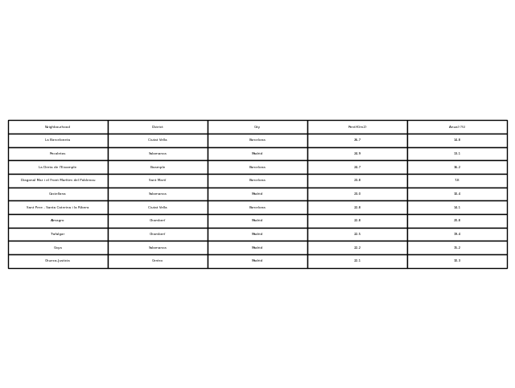

```python
#We use this command to display the table
fig, ax = plt.subplots(figsize=(8, 6))
# Turn off the axis
ax.axis('off')
ax.table(cellText=subset_spanishrentB.values, colLabels=subset_spanishrentB.columns,
         cellLoc='center', loc='center')
# Save the figure as a PNG image
plt.savefig('table_image.png', bbox_inches='tight')
```

The visualization is not very clear nor aesthetic. However we can save the dataset so we can use it to create a nicer table using Datawrapper.

```python
# I save the dataset and import it as a csv file
subset_spanishrentB.to_csv('subset_spanishrentB.csv')
```

Now I will start working on the other datasets to start doing some comparisons between income and rent. Note that in each dataset there is a column for districts and a column for neighbourhoods. Barcelona is divided in 10 districts and each district has different neighbourhoods. The total number of neighbourhoods is 73. The datasets usually contain information specific to each neighbourhood and we can always see in which district each neighbourhood belongs.

```python
# We first import and name the datasets
income21=pd.read_csv('income.csv')
```

```python
income21.head()
```

|  | Any | Codi_Districte | Nom_Districte | Codi_Barri | Nom_Barri | Seccio_Censal | Import_Renda_Bruta_€ |
| --- | --- | --- | --- | --- | --- | --- | --- |
| 0 | 2021 | 1 | Ciutat Vella | 1 | el Raval | 1 | 13657 |
| 1 | 2021 | 1 | Ciutat Vella | 1 | el Raval | 2 | 10724 |
| 2 | 2021 | 1 | Ciutat Vella | 1 | el Raval | 3 | 11017 |
| 3 | 2021 | 1 | Ciutat Vella | 1 | el Raval | 4 | 13156 |
| 4 | 2021 | 1 | Ciutat Vella | 1 | el Raval | 5 | 11426 |

```python
#I check for misisng values
income21.isna().sum()
```

```
Any                     0
Codi_Districte          0
Nom_Districte           0
Codi_Barri              0
Nom_Barri               0
Seccio_Censal           0
Import_Renda_Bruta_€    0
dtype: int64
```

I will continue exploring the data using the different commands:

```python
income21.info()
```

```
<class 'pandas.core.frame.DataFrame'>
RangeIndex: 1068 entries, 0 to 1067
Data columns (total 7 columns):
 #   Column                Non-Null Count  Dtype
---  ------                --------------  -----
 0   Any                   1068 non-null   int64
 1   Codi_Districte        1068 non-null   int64
 2   Nom_Districte         1068 non-null   object
 3   Codi_Barri            1068 non-null   int64
 4   Nom_Barri             1068 non-null   object
 5   Seccio_Censal         1068 non-null   int64
 6   Import_Renda_Bruta_€  1068 non-null   int64
dtypes: int64(5), object(2)
memory usage: 58.5+ KB
```

```python
income21.describe()
```

|  | Any | Codi_Districte | Codi_Barri | Seccio_Censal | Import_Renda_Bruta_€ |
| --- | --- | --- | --- | --- | --- |
| count | 1068.0 | 1068.000000 | 1068.000000 | 1068.000000 | 1068.000000 |
| mean | 2021.0 | 5.723783 | 33.246255 | 60.645131 | 22447.893258 |
| std | 0.0 | 2.938532 | 21.892988 | 41.569541 | 7617.605339 |
| min | 2021.0 | 1.000000 | 1.000000 | 1.000000 | 7845.000000 |
| 25% | 2021.0 | 3.000000 | 13.000000 | 27.750000 | 17561.250000 |
| 50% | 2021.0 | 6.000000 | 31.000000 | 54.000000 | 21160.500000 |
| 75% | 2021.0 | 8.000000 | 52.000000 | 87.000000 | 25198.500000 |
| max | 2021.0 | 10.000000 | 73.000000 | 237.000000 | 46570.000000 |

I will clean the table a little bit. I rename the columns and get rid of column 'Codi_Districte', 'Codi_Barri' and 'Seccio_Censal':

```python
incomeB=income21.rename(columns={'Any': 'Year', 'Nom_Districte': 'District',
                                   	'Nom_Barri':'Neighbourhood','Import_Renda_Bruta_€':'Income'})
incomeB.drop(['Codi_Districte','Codi_Barri','Seccio_Censal'], axis = 1, inplace = True)
#Income here refers to income before taxes
```

```python
incomeB.head()
```

|  | Year | District | Neighbourhood | Income |
| --- | --- | --- | --- | --- |
| 0 | 2021 | Ciutat Vella | el Raval | 13657 |
| 1 | 2021 | Ciutat Vella | el Raval | 10724 |
| 2 | 2021 | Ciutat Vella | el Raval | 11017 |
| 3 | 2021 | Ciutat Vella | el Raval | 13156 |
| 4 | 2021 | Ciutat Vella | el Raval | 11426 |

In the dataset above we can see that each neighbourhood is repeated many times. This is because the dataset gives information about the income of each census sections. To try to make this a bit more simple we will merge the rows with the same neighbourhood name to end up with the average income for each neighbourhood.

```python
#Merge the dataset
result_incomeB = incomeB.groupby('Neighbourhood')['Income'].mean().reset_index()
#We want to get a result of the income with only two decimals
result_incomeB['Income'] = result_incomeB['Income'].round(2)
```

```python
result_incomeB
```

|  | Neighbourhood | Income |
| --- | --- | --- |
| 0 | Baró de Viver | 11486.00 |
| 1 | Can Baró | 19899.00 |
| 2 | Can Peguera | 12330.50 |
| 3 | Canyelles | 17804.20 |
| 4 | Ciutat Meridiana | 10054.00 |
| ... | ... | ... |
| 68 | la Vila Olímpica del Poblenou | 32517.60 |
| 69 | la Vila de Gràcia | 24005.39 |
| 70 | les Corts | 29606.17 |
| 71 | les Roquetes | 12304.90 |
| 72 | les Tres Torres | 44280.36 |

73 rows × 2 columns

I can see this is right because as I noted earlier, Barcelona has 73 neighbourhoods in total, which is the number of rows in the table. When I start working with the rent datasets I will see that they give monthly values. Therefore I will try to get monthly income values to be able to compare both.

```python
#We add a column assuming that income is evenly distributed throughout the year.
result_incomeB['Monthly Income'] = result_incomeB['Income']/12
result_incomeB['Monthly Income'] = result_incomeB['Monthly Income'].round(2)
```

```python
result_incomeB
```

|  | Neighbourhood | Income | Monthly Income |
| --- | --- | --- | --- |
| 0 | Baró de Viver | 11486.00 | 957.17 |
| 1 | Can Baró | 19899.00 | 1658.25 |
| 2 | Can Peguera | 12330.50 | 1027.54 |
| 3 | Canyelles | 17804.20 | 1483.68 |
| 4 | Ciutat Meridiana | 10054.00 | 837.83 |
| ... | ... | ... | ... |
| 68 | la Vila Olímpica del Poblenou | 32517.60 | 2709.80 |
| 69 | la Vila de Gràcia | 24005.39 | 2000.45 |
| 70 | les Corts | 29606.17 | 2467.18 |
| 71 | les Roquetes | 12304.90 | 1025.41 |
| 72 | les Tres Torres | 44280.36 | 3690.03 |

73 rows × 3 columns

Now I will try to make a visualization of the average income of each neighbourhood to see the differences between each more clearly. The library Matplotlib will allow me to do this visualization. When trying to plot the 73 neighbourhoods, the names in the x-axis did not fit and overlapped so it was not possible to read them. Therefore I decided to do a plot that only contains the neighbouhoods with a monthly income below 1.500€.

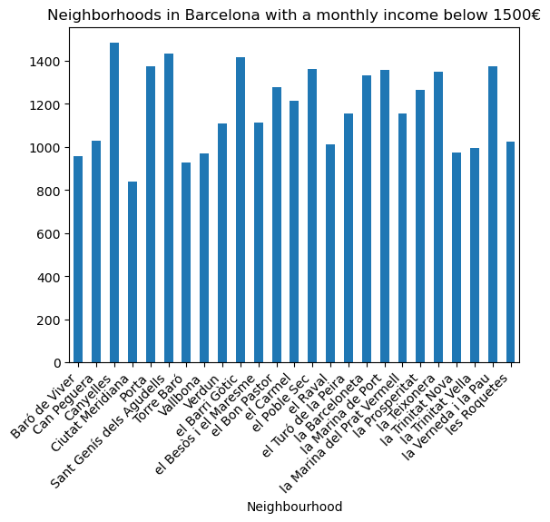

```python
#We filter and choose those which have an income <1500. We will also add a title to the plot
filtered_result_incomeB = result_incomeB[result_incomeB['Monthly Income'] < 1500]
plt.figure(figsize=(15, 8))
ax = filtered_result_incomeB.plot(kind='bar', x='Neighbourhood', y='Monthly Income', legend=False)
ax.set_xticks(ax.get_xticks())
ax.set_xticklabels(filtered_result_incomeB['Neighbourhood'], rotation=45, ha='right')
ax.set_title('Neighborhoods in Barcelona with a monthly income below 1500€')
ax.width = 1000
plt.show()
#we import the plot
plt.savefig ('myplot.png')
```

I can see that La Barceloneta is among the 25 neighborhoods with lower monthly income out of a total of 73 neighborhoods in Barcelona. However I'm not happy with only this visualization so I will try to do it using the tool Bokeh.

```python
#We install bokeh
```

```python
pip install bokeh
```

```python
#We install selenium in order to be able to export bokeh png figures
```

```python
pip install selenium
```

```python
from bokeh.plotting import figure, output_notebook, show
from bokeh.io import export_png #we also import this module to allow us to export figures as png files
# Set up Bokeh for JupyterLab
output_notebook()
```

Loading BokehJS ...

Once Bokeh library is loaded I create a new dataframe to work with this tool, but the dataframe will be the same one I used earlier, I just don't want to change the original.

```python
result_incomeB_bar = pd.DataFrame(result_incomeB)

# We create a bar graph
p = figure(x_range=result_incomeB['Neighbourhood'], title='Monthly income by neighborhood (€)',
           x_axis_label='Neighbourhood', y_axis_label='Monthly Income')

p.vbar(x='Neighbourhood', top='Monthly Income', source=result_incomeB, width=0.5, color='orange')
p.xaxis.major_label_orientation = 45  # Adjust the angle as needed
p.width = 1000  # set the width of the plot (in pixels)
# Show the plot
show(p)
```

```python
#I export the figure as a png file
export_png(p, filename="bar_graph.png")
```

[output not shown]

```python
#I will filter and choose those which have an income below <1500.
filtered_result_incomeB = result_incomeB[result_incomeB['Monthly Income'] < 1500]
p = figure(x_range=filtered_result_incomeB['Neighbourhood'], title='Neighborhoods in Barcelona with a monthly income below 1500€',
           x_axis_label='Neighbourhood', y_axis_label='Monthly Income')

p.vbar(x='Neighbourhood', top='Monthly Income', source=result_incomeB, width=0.5, color='purple')
p.xaxis.major_label_orientation = 45  # Adjust the angle as needed
p.width = 800 # set the width of the plot (in pixels)
# Show the plot
show(p)
```

```python
#We export the figure as a png file
export_png(p,filename="bar_graph2.png")
```

```
'/Users/bertaolivier/Desktop/Data Journalism/FINAL PROJECT/bar_graph2.png'
```

As I explained at the start of this notebook, the fact that La Barceloneta appeared as the most expensive neighbourhood in Spain (according to Idealista) was quite surpring given the fact that this area has never had high incomes. So after we loaded the income dataset I want to specifically see the average income value for this neighbourhood in 2021 (latest data available).

```python
#we look within the dataset
inc_barceloneta21=result_incomeB.loc[result_incomeB['Neighbourhood']=='la Barceloneta']
```

```python
inc_barceloneta21
```

|  | Neighbourhood | Income | Monthly Income |
| --- | --- | --- | --- |
| 48 | la Barceloneta | 15986.55 | 1332.21 |

After this first exploration and visualization I will upload two more datasets that refer to the average income of each neighbourhood from 2020 and 2019, just the same way as we did with the one from 2021.

```python
# I import and name the dataset
income20=pd.read_csv('income20.csv')
```

```python
#I clean and rename the dataset
income_20=income20.rename(columns={'Any': 'Year', 'Nom_Districte': 'District',
                                   	'Nom_Barri':'Neighbourhood','Import_Renda_Bruta_€':'Income'})
income_20.drop(['Codi_Districte','Codi_Barri','Seccio_Censal'], axis = 1, inplace = True)
#Income here refers to income before taxes
income_20.head()
```

|  | Year | District | Neighbourhood | Income |
| --- | --- | --- | --- | --- |
| 0 | 2020 | Ciutat Vella | el Raval | 12798 |
| 1 | 2020 | Ciutat Vella | el Raval | 9727 |
| 2 | 2020 | Ciutat Vella | el Raval | 9932 |
| 3 | 2020 | Ciutat Vella | el Raval | 12318 |
| 4 | 2020 | Ciutat Vella | el Raval | 10575 |

```python
#Merge the dataset to get the average income for each neighbourhood, deleting the census sections
avincome_20 = income_20.groupby('Neighbourhood')['Income'].mean().reset_index()
#I want to get a result of the income with only two decimals
avincome_20['Income'] = avincome_20['Income'].round(2)
#I add a column assuming that income is evenly distributed throughout the year.
avincome_20['Monthly Income'] = avincome_20['Income']/12
avincome_20['Monthly Income'] = avincome_20['Monthly Income'].round(2)
```

```python
avincome_20
```

|  | Neighbourhood | Income | Monthly Income |
| --- | --- | --- | --- |
| 0 | Baró de Viver | 10774.00 | 897.83 |
| 1 | Can Baró | 19069.29 | 1589.11 |
| 2 | Can Peguera | 11544.50 | 962.04 |
| 3 | Canyelles | 16981.60 | 1415.13 |
| 4 | Ciutat Meridiana | 9485.17 | 790.43 |
| ... | ... | ... | ... |
| 68 | la Vila Olímpica del Poblenou | 31135.20 | 2594.60 |
| 69 | la Vila de Gràcia | 22788.72 | 1899.06 |
| 70 | les Corts | 28510.09 | 2375.84 |
| 71 | les Roquetes | 11694.70 | 974.56 |
| 72 | les Tres Torres | 42970.73 | 3580.89 |

73 rows × 3 columns

```python
#I look within the dataset
inc_barceloneta20=avincome_20.loc[avincome_20['Neighbourhood']=='la Barceloneta']
```

```python
inc_barceloneta20
```

|  | Neighbourhood | Income | Monthly Income |
| --- | --- | --- | --- |
| 48 | la Barceloneta | 14743.64 | 1228.64 |

```python
#I do it one last time with income from 2019
#I import and name the dataset
income19=pd.read_csv('income19.csv')
```

```python
#we clean and rename the dataset
avincome_19=income19.rename(columns={'Any': 'Year','Nom_Districte':'District',
                                   	'Nom_Barri':'Neighbourhood','Import_Renda_Bruta_€                ':'Income'})

avincome_19.drop(['Codi_Districte','Codi_Barri','Seccio_Censal'], axis = 1, inplace = True)
#Income here refers to income before taxes
income_20.head()
avincome_19
```

|  | Year | District | Neighbourhood | Income |
| --- | --- | --- | --- | --- |
| 0 | 2019 | Ciutat Vella | el Raval | 13022 |
| 1 | 2019 | Ciutat Vella | el Raval | 10797 |
| 2 | 2019 | Ciutat Vella | el Raval | 10281 |
| 3 | 2019 | Ciutat Vella | el Raval | 12875 |
| 4 | 2019 | Ciutat Vella | el Raval | 10810 |
| ... | ... | ... | ... | ... |
| 1063 | 2019 | Sant Martí | la Verneda i la Pau | 14130 |
| 1064 | 2019 | Sant Martí | el Clot | 17714 |
| 1065 | 2019 | Sant Martí | Diagonal Mar i el Front Marítim del Poblenou | 15756 |
| 1066 | 2019 | Sant Martí | Diagonal Mar i el Front Marítim del Poblenou | 16748 |
| 1067 | 2019 | Sant Martí | Provençals del Poblenou | 14993 |

1068 rows × 4 columns

```python
print(avincome_19.columns)
```

```
Index(['Year', 'District', 'Neighbourhood', 'Income'], dtype='object')
```

```python
#Merge the dataset to get the average income for each neighbourhood, deleting the census sections
avincome_19 = avincome_19.groupby('Neighbourhood')['Income'].mean().reset_index()#We want to get a result of the income with only two decimals
avincome_19['Income'] = avincome_19['Income'].round(2)
#I add a column assuming that income is evenly distributed throughout the year.
avincome_19['Monthly Income'] = avincome_19['Income']/12
avincome_19['Monthly Income'] = avincome_19['Monthly Income'].round(2)
avincome_19
```

|  | Neighbourhood | Income | Monthly Income |
| --- | --- | --- | --- |
| 0 | Baró de Viver | 10581.50 | 881.79 |
| 1 | Camp de l'Arpa del Clot | 19523.68 | 1626.97 |
| 2 | Can Baró | 18668.57 | 1555.71 |
| 3 | Can Peguera | 11609.00 | 967.42 |
| 4 | Canyelles | 16819.20 | 1401.60 |
| ... | ... | ... | ... |
| 68 | la Verneda i la Pau | 15612.14 | 1301.01 |
| 69 | la Vila Olímpica del Poblenou | 31853.20 | 2654.43 |
| 70 | les Corts | 28655.43 | 2387.95 |
| 71 | les Roquetes | 11673.60 | 972.80 |
| 72 | les Tres Torres | 44188.91 | 3682.41 |

73 rows × 3 columns

Now we would like to make a graph that allow us to visualize the evolution of the average income per neighbourhood in Barcelona in the last three years (from 2019 to 2021). To do so we will use seaborn and matplotlib.

```python
#First I merge the three dataframes to have only one
avbcninc = pd.merge(avincome_19, avincome_20, on='Neighbourhood', suffixes=('_2019', '_2020'))
avbcn_inc = pd.merge(avbcninc, result_incomeB, on='Neighbourhood')

#I replace NaN with 0
avbcn_inc = avbcn_inc.fillna(0)

#I rename and display the new dataframe
avbcn_inc=avbcn_inc.rename(columns={'Income	': 'Income_2021','Income':'Income_2021','Monthly Income':'Monthly Income_2021'})
avbcn_inc
```

|  | Neighbourhood | Income_2019 | Monthly Income_2019 | Income_2020 | Monthly Income_2020 | Income_2021 | Monthly Income_2021 |
| --- | --- | --- | --- | --- | --- | --- | --- |
| 0 | Baró de Viver | 10581.50 | 881.79 | 10774.00 | 897.83 | 11486.00 | 957.17 |
| 1 | Can Baró | 18668.57 | 1555.71 | 19069.29 | 1589.11 | 19899.00 | 1658.25 |
| 2 | Can Peguera | 11609.00 | 967.42 | 11544.50 | 962.04 | 12330.50 | 1027.54 |
| 3 | Canyelles | 16819.20 | 1401.60 | 16981.60 | 1415.13 | 17804.20 | 1483.68 |
| 4 | Ciutat Meridiana | 9556.33 | 796.36 | 9485.17 | 790.43 | 10054.00 | 837.83 |
| ... | ... | ... | ... | ... | ... | ... | ... |
| 61 | la Verneda i la Pau | 15612.14 | 1301.01 | 15724.00 | 1310.33 | 16520.10 | 1376.68 |
| 62 | la Vila Olímpica del Poblenou | 31853.20 | 2654.43 | 31135.20 | 2594.60 | 32517.60 | 2709.80 |
| 63 | les Corts | 28655.43 | 2387.95 | 28510.09 | 2375.84 | 29606.17 | 2467.18 |
| 64 | les Roquetes | 11673.60 | 972.80 | 11694.70 | 974.56 | 12304.90 | 1025.41 |
| 65 | les Tres Torres | 44188.91 | 3682.41 | 42970.73 | 3580.89 | 44280.36 | 3690.03 |

66 rows × 7 columns

```python
print(avbcn_inc.columns)
```

```
Index(['Neighbourhood', 'Income_2019', 'Monthly Income_2019', 'Income_2020',
       'Monthly Income_2020', 'Income_2021', 'Monthly Income_2021'],
      dtype='object')
```

After merging the three dataframes we want to create a barplot with grouped values so that we can see the evolution the income value for each neighbourhood.

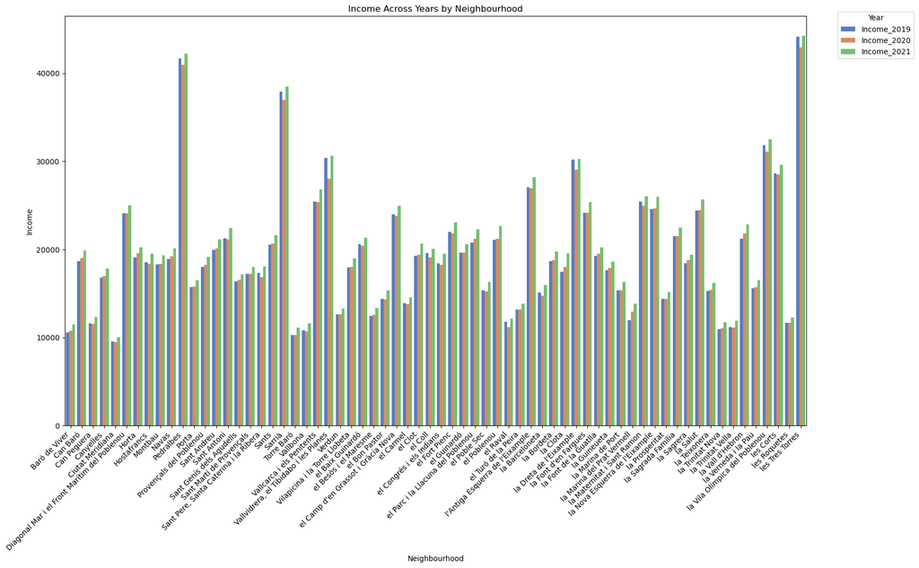

```python
#I melt the DataFrame to have a 'variable' column for the years and a 'value' column for the income
avbcn_inc = pd.melt(avbcn_inc, id_vars=['Neighbourhood'], value_vars=['Income_2019', 'Income_2020', 'Income_2021'],
                    var_name='Year', value_name='Income')

#I create a grouped bar plot
plt.figure(figsize=(18, 10)) #we can try different sizes to see whcih one can fit better all the names in the x-axis
sns.barplot(x='Neighbourhood', y='Income', hue='Year', data=avbcn_inc, palette='muted')

#I customize the plot
plt.title('Income Across Years by Neighbourhood')
plt.xlabel('Neighbourhood')
plt.ylabel('Income')
plt.xticks(rotation=45, ha='right')  #Rotate x-axis labels for better readability
plt.legend(title='Year', bbox_to_anchor=(1.15,1.02))
#I import the plot as a PNG
plt.savefig ('avbcn_inc.png')
plt.show()
```

I will now look at the dataset regarding the rent. The data currently accessible is more up-to-date and encompasses rental price information up to the second quarter of 2023. I will see that the data is divided in terms.

```python
#average rent in each neighbourhood
rent=pd.read_csv('bcn_rent.csv')
```

```python
#some basic descriptives
rent.describe()
```

|  | Any | Trimestre | Codi_Districte | Codi_Barri | Preu |
| --- | --- | --- | --- | --- | --- |
| count | 292.0 | 292.000000 | 292.000000 | 292.000000 | 273.000000 |
| mean | 2023.0 | 1.500000 | 6.246575 | 37.000000 | 530.094505 |
| std | 0.0 | 0.500858 | 2.793123 | 21.107481 | 549.194713 |
| min | 2023.0 | 1.000000 | 1.000000 | 1.000000 | 6.200000 |
| 25% | 2023.0 | 1.000000 | 4.000000 | 19.000000 | 15.200000 |
| 50% | 2023.0 | 1.500000 | 7.000000 | 37.000000 | 491.900000 |
| 75% | 2023.0 | 2.000000 | 8.000000 | 55.000000 | 971.100000 |
| max | 2023.0 | 2.000000 | 10.000000 | 73.000000 | 1901.000000 |

```python
rent.head()
```

|  | Any | Trimestre | Codi_Districte | Nom_Districte | Codi_Barri | Nom_Barri | Lloguer_mitja | Preu |
| --- | --- | --- | --- | --- | --- | --- | --- | --- |
| 0 | 2023 | 1 | 1 | Ciutat Vella | 1 | el Raval | Lloguer mitjà mensual (Euros/mes) | 946.8 |
| 1 | 2023 | 1 | 1 | Ciutat Vella | 2 | el Barri Gòtic | Lloguer mitjà mensual (Euros/mes) | 1279.5 |
| 2 | 2023 | 1 | 1 | Ciutat Vella | 3 | la Barceloneta | Lloguer mitjà mensual (Euros/mes) | 978.7 |
| 3 | 2023 | 1 | 1 | Ciutat Vella | 4 | Sant Pere, Santa Caterina i la Ribera | Lloguer mitjà mensual (Euros/mes) | 1065.8 |
| 4 | 2023 | 1 | 2 | Eixample | 5 | el Fort Pienc | Lloguer mitjà mensual (Euros/mes) | 1155.8 |

I can see that my dataframe is quite large. Moreover it provides both the average monthly rent and the average price per square meter. So I decide to separate them into two new dataframes.

```python
#First I create a dataframe containing the average price per square meter
avm2_month = rent[rent["Lloguer_mitja"]=='Lloguer mitjà per superfície (Euros/m2 mes)']
```

```python
avm2_month.head()
```

|  | Any | Trimestre | Codi_Districte | Nom_Districte | Codi_Barri | Nom_Barri | Lloguer_mitja | Preu |
| --- | --- | --- | --- | --- | --- | --- | --- | --- |
| 73 | 2023 | 1 | 1 | Ciutat Vella | 1 | el Raval | Lloguer mitjà per superfície (Euros/m2 mes) | 15.8 |
| 74 | 2023 | 1 | 1 | Ciutat Vella | 2 | el Barri Gòtic | Lloguer mitjà per superfície (Euros/m2 mes) | 16.6 |
| 75 | 2023 | 1 | 1 | Ciutat Vella | 3 | la Barceloneta | Lloguer mitjà per superfície (Euros/m2 mes) | 18.0 |
| 76 | 2023 | 1 | 1 | Ciutat Vella | 4 | Sant Pere, Santa Caterina i la Ribera | Lloguer mitjà per superfície (Euros/m2 mes) | 16.6 |
| 77 | 2023 | 1 | 2 | Eixample | 5 | el Fort Pienc | Lloguer mitjà per superfície (Euros/m2 mes) | 15.9 |

```python
#Second I create a dataframe containing the average monthly rent
avrent_month = rent[rent["Lloguer_mitja"]=='Lloguer mitjà mensual (Euros/mes)']
```

```python
avrent_month.head()
```

|  | Any | Trimestre | Codi_Districte | Nom_Districte | Codi_Barri | Nom_Barri | Lloguer_mitja | Preu |
| --- | --- | --- | --- | --- | --- | --- | --- | --- |
| 0 | 2023 | 1 | 1 | Ciutat Vella | 1 | el Raval | Lloguer mitjà mensual (Euros/mes) | 946.8 |
| 1 | 2023 | 1 | 1 | Ciutat Vella | 2 | el Barri Gòtic | Lloguer mitjà mensual (Euros/mes) | 1279.5 |
| 2 | 2023 | 1 | 1 | Ciutat Vella | 3 | la Barceloneta | Lloguer mitjà mensual (Euros/mes) | 978.7 |
| 3 | 2023 | 1 | 1 | Ciutat Vella | 4 | Sant Pere, Santa Caterina i la Ribera | Lloguer mitjà mensual (Euros/mes) | 1065.8 |
| 4 | 2023 | 1 | 2 | Eixample | 5 | el Fort Pienc | Lloguer mitjà mensual (Euros/mes) | 1155.8 |

As we have been doing with the other dataframes, we will rename the columns and put labels in English instead.

```python
#Rename and get rid of column 'Codi_Districte'and 'Codi_Barri', 'Lloguer mitja'
avm2_month=avm2_month.rename(columns={'Any': 'Year', 'Trimestre':'Term','Nom_Districte': 'District',
                                   	'Nom_Barri':'Neighbourhood','Preu':'Average €/m2'})
avm2_month.drop(['Codi_Districte','Codi_Barri','Lloguer_mitja'],axis = 1,inplace = True)
```

```python
avm2_month
```

|  | Year | Term | District | Neighbourhood | Average €/m2 |
| --- | --- | --- | --- | --- | --- |
| 73 | 2023 | 1 | Ciutat Vella | el Raval | 15.8 |
| 74 | 2023 | 1 | Ciutat Vella | el Barri Gòtic | 16.6 |
| 75 | 2023 | 1 | Ciutat Vella | la Barceloneta | 18.0 |
| 76 | 2023 | 1 | Ciutat Vella | Sant Pere, Santa Caterina i la Ribera | 16.6 |
| 77 | 2023 | 1 | Eixample | el Fort Pienc | 15.9 |
| ... | ... | ... | ... | ... | ... |
| 287 | 2023 | 2 | Sant Martí | Diagonal Mar i el Front Marítim del Poblenou | 19.2 |
| 288 | 2023 | 2 | Sant Martí | el Besòs i el Maresme | 11.9 |
| 289 | 2023 | 2 | Sant Martí | Provençals del Poblenou | 16.7 |
| 290 | 2023 | 2 | Sant Martí | Sant Martí de Provençals | 13.2 |
| 291 | 2023 | 2 | Sant Martí | la Verneda i la Pau | 14.5 |

146 rows × 5 columns

```python
#I sort the rows in descending order
eurosm2= avm2_month.sort_values(by='Average €/m2', ascending=False)
```

```python
eurosm2
```

|  | Year | Term | District | Neighbourhood | Average €/m2 |
| --- | --- | --- | --- | --- | --- |
| 88 | 2023 | 1 | Sants-Montjuïc | la Bordeta | 22.9 |
| 285 | 2023 | 2 | Sant Martí | la Vila Olímpica del Poblenou | 21.2 |
| 234 | 2023 | 2 | Sants-Montjuïc | la Bordeta | 21.1 |
| 242 | 2023 | 2 | Sarrià-Sant Gervasi | les Tres Torres | 20.2 |
| 241 | 2023 | 2 | Sarrià-Sant Gervasi | Sarrià | 19.6 |
| ... | ... | ... | ... | ... | ... |
| 260 | 2023 | 2 | Horta-Guinardó | la Clota | NaN |
| 265 | 2023 | 2 | Nou Barris | Can Peguera | NaN |
| 272 | 2023 | 2 | Nou Barris | Torre Baró | NaN |
| 274 | 2023 | 2 | Nou Barris | Vallbona | NaN |
| 276 | 2023 | 2 | Sant Andreu | Baró de Viver | NaN |

146 rows × 5 columns

```python
#I rename the second table.
avrent_month=avrent_month.rename(columns={'Any': 'Year','Trimestre':'Term','Nom_Districte': 'District',
                                   	'Nom_Barri':'Neighbourhood','Preu':'Monthly Rent'})
avrent_month.drop(['Codi_Districte','Codi_Barri','Lloguer_mitja'],axis = 1,inplace = True)
```

```python
avrent_month
```

|  | Year | Term | District | Neighbourhood | Monthly Rent |
| --- | --- | --- | --- | --- | --- |
| 0 | 2023 | 1 | Ciutat Vella | el Raval | 946.8 |
| 1 | 2023 | 1 | Ciutat Vella | el Barri Gòtic | 1279.5 |
| 2 | 2023 | 1 | Ciutat Vella | la Barceloneta | 978.7 |
| 3 | 2023 | 1 | Ciutat Vella | Sant Pere, Santa Caterina i la Ribera | 1065.8 |
| 4 | 2023 | 1 | Eixample | el Fort Pienc | 1155.8 |
| ... | ... | ... | ... | ... | ... |
| 214 | 2023 | 2 | Sant Martí | Diagonal Mar i el Front Marítim del Poblenou | 1400.6 |
| 215 | 2023 | 2 | Sant Martí | el Besòs i el Maresme | 746.9 |
| 216 | 2023 | 2 | Sant Martí | Provençals del Poblenou | 1204.2 |
| 217 | 2023 | 2 | Sant Martí | Sant Martí de Provençals | 960.9 |
| 218 | 2023 | 2 | Sant Martí | la Verneda i la Pau | 991.1 |

146 rows × 5 columns

```python
#I sort the rows in descending order
eurosmonth= avrent_month.sort_values(by='Monthly Rent', ascending=False)
```

```python
eurosmonth
```

|  | Year | Term | District | Neighbourhood | Monthly Rent |
| --- | --- | --- | --- | --- | --- |
| 20 | 2023 | 1 | Les Corts | Pedralbes | 1901.0 |
| 169 | 2023 | 2 | Sarrià-Sant Gervasi | les Tres Torres | 1859.8 |
| 23 | 2023 | 1 | Sarrià-Sant Gervasi | les Tres Torres | 1750.2 |
| 171 | 2023 | 2 | Sarrià-Sant Gervasi | Sant Gervasi - Galvany | 1730.5 |
| 166 | 2023 | 2 | Les Corts | Pedralbes | 1728.4 |
| ... | ... | ... | ... | ... | ... |
| 187 | 2023 | 2 | Horta-Guinardó | la Clota | NaN |
| 192 | 2023 | 2 | Nou Barris | Can Peguera | NaN |
| 199 | 2023 | 2 | Nou Barris | Torre Baró | NaN |
| 201 | 2023 | 2 | Nou Barris | Vallbona | NaN |
| 203 | 2023 | 2 | Sant Andreu | Baró de Viver | NaN |

146 rows × 5 columns

```python
#I use this comand to see the names of each neighbourhood in my dataframe and look for La Barceloneta
print(avm2_month ['Neighbourhood'].unique())
```

```
['el Raval' 'el Barri Gòtic' 'la Barceloneta'
 'Sant Pere, Santa Caterina i la Ribera' 'el Fort Pienc'
 'la Sagrada Família' "la Dreta de l'Eixample"
 "l'Antiga Esquerra de l'Eixample" "la Nova Esquerra de l'Eixample"
 'Sant Antoni' 'el Poble Sec' 'la Marina del Prat Vermell'
 'la Marina de Port' 'la Font de la Guatlla' 'Hostafrancs' 'la Bordeta'
 'Sants - Badal' 'Sants' 'les Corts' 'la Maternitat i Sant Ramon'
 'Pedralbes' 'Vallvidrera, el Tibidabo i les Planes' 'Sarrià'
 'les Tres Torres' 'Sant Gervasi - la Bonanova' 'Sant Gervasi - Galvany'
 'el Putxet i el Farró' 'Vallcarca i els Penitents' 'el Coll' 'la Salut'
 'la Vila de Gràcia' "el Camp d'en Grassot i Gràcia Nova"
 'el Baix Guinardó' 'Can Baró' 'el Guinardó' "la Font d'en Fargues"
 'el Carmel' 'la Teixonera' 'Sant Genís dels Agudells' 'Montbau'
 "la Vall d'Hebron" 'la Clota' 'Horta' 'Vilapicina i la Torre Llobeta'
 'Porta' 'el Turó de la Peira' 'Can Peguera' 'la Guineueta' 'Canyelles'
 'les Roquetes' 'Verdun' 'la Prosperitat' 'la Trinitat Nova' 'Torre Baró'
 'Ciutat Meridiana' 'Vallbona' 'la Trinitat Vella' 'Baró de Viver'
 'el Bon Pastor' 'Sant Andreu' 'la Sagrera' 'el Congrés i els Indians'
 'Navas' "el Camp de l'Arpa del Clot" 'el Clot'
 'el Parc i la Llacuna del Poblenou' 'la Vila Olímpica del Poblenou'
 'el Poblenou' 'Diagonal Mar i el Front Marítim del Poblenou'
 'el Besòs i el Maresme' 'Provençals del Poblenou'
 'Sant Martí de Provençals' 'la Verneda i la Pau']
```